**2022年度 東京成徳大学 特別講座 資料**  
**東京工科大学コンピュータサイエンス学部**  
**福西広晃**

# 特別講習の内容

## 第01回 Python基礎1（計算機能の実装）

- 画面表示、変数、選択（条件文）

## 第02回 Python基礎2（計算機能の実装）

- 反復（繰り返し文）、リスト

## 第03回 Pythonによるテーブルデータの操作と統計計算

- Pandasライブラリ

## 第04回 Pythonによるデータ可視化

- matplotlibライブラリ

## 第05回 Pythonによる実践的なデータ分析

- 株価分析

# なんのためにプログラミングを行うのか

業務（作業）の自動化 → 業務（作業）効率化

# プログラミング言語Pythonについて

- 本講義では、プログラミング言語として`Python`を用いる
- `Python`は近年最も人気のあるプログラミング言語の１つである

## Pythonの特徴

- プログラミング言語としての仕様がわかりやすい（文法がシンプル）
- オープンソース（無料で利用できる）
- 豊富な標準ライブラリと外部のパッケージ（便利機能をもとアプリを想像してください）
- コンパイル不要（スクリプト言語）
  - コンパイルとは、プログラミング言語で書かれた文字列（ソースコード）を、コンピュータ上で実行可能な形式（オブジェクトコード）に変換すること
- 汎用性が高い（以下に紹介）

## Pythonは何に使われているか

- `Webアプリ開発`
  - Instagram, YoutubeなどはPythonで書かれている
  - Django, Flaskなどのフレームワークを用いれば、効率よく開発できる(フレームワークとは、アプリケーションを開発する際によく使われる機能がまとまったソフトウェアのこと)
- `機械学習プログラミング(AI開発)`
  - AI分野において、Pythonはデファクトスタンダードとなっている
  - Scilit-learn, TensorFlow, PyTorch等のライブラリを用いれば、予測モデルが生成できる
- `データサイエンス`
  - Pandas, Matplotlib, Seabornn等のライブラリを用いれば、統計解析やデータの可視化ができる
- `Webスクレイピング（Webサイトからのデータ取得）`
  - htmlの知識があれば、BeautifulSoup, Seleniumのライブラリを用いてWebサイトから効率的にデータを取得できる
- `Excelの自動処理`
- `ゲーム開発`
- `株やFXの自動売買`
- `ブロックチェーン開発（暗号化技術）`

## Pythonの開発環境

- `オンライン(クラウドサービス)`  
  インターネットに繋がるブラウザがあればいつでもどこでも利用できる（スマートフォンでもOK）
  - **Google Colaboratory**：グーグル社が提供、対話型実行環境が利用できる、面倒な環境構築が不要で初学者の学習環境として最もメジャーな環境
  - AWS Cloud9：Amazon社が提供
- `オフライン(ローカルPCで開発)`  
  ローカルPCにインストールして利用するため利用場所が制限される
  - Python(Pure Python): コマンドラインで実行
  - **Anaconda**: Anaconda社が提供、Jupyter NotebookやJupyter Labの対話型実行環境が利用できる、分析用途で広く利用されている環境、
  - Visual Studio Code: マイクロソフト社が提供（Webアプリの開発で広く利用されている環境）

# Google Colaboratoryの使い方

- Google ChromeやMicrosoft Edgeなどのブラウザを使ってプログラミングを行う
- Jupyter Notebook（読み方は「ジュパイター・ノートブック」または「ジュピター・ノートブック」）がベースとなっており、1セルごとにプログラムを実行・確認することができる（対話型実行環境とも呼ばれる）
- プログラムとその実行結果やその際のメモを簡単に作成でき、過去の作業内容の振り返りや、チームメンバーへ作業結果を共有する際に便利な他、授業や研修等の利用に適している
- 拡張機能（nbextensions）を導入すれば、利便性を向上できる

[figure not shown]

# Jupyter Notebookの使い方[Anaconda用]

## 概要

- Jupyter Notebookの読み方は「ジュパイター・ノートブック」または「ジュピター・ノートブック」)
- Google ChromeやMicrosoft Edgeなどのブラウザを使ってプログラミングを行う
- 1セルごとにプログラムを実行・確認することができる（`対話型実行環境`とも呼ばれる）
- プログラムとその実行結果やその際のメモを簡単に作成でき、過去の作業内容の振り返りや、チームメンバーへ作業結果を共有する際に便利な他、授業や研修等の利用に適している
- 拡張機能（nbextensions）を導入すれば、利便性を向上できる

[figure not shown]

## nbextensionsのインストール（Jupyter Notebookの拡張機能）

- Anaconda promptで以下を実行
  - `conda install -c conda-forge jupyter_contrib_nbextensions`
  - `jupyter nbextensions_configurator enable --user`
  - `conda install -c conda-forge/label/cf202003 jupyter_contrib_nbextensions`
  - [参考](https://stackoverflow.com/questions/62763031/jupyter-configurable-nbextensions-list-is-empty)

## 拡張機能の追加

- Nbextensionsタブを開いて、「disable configuration・・・」のチェック外して必要な拡張機能にチェックを入れる
- 推奨の拡張機能
  - Table of Contents : 目次を追加する
  - Variable Inspector : 変数の一覧を表示する
  - Hinterland : 入力補完を使えるようにする
  - Codefolding : セル内のコードを折り畳めるようにする
- 拡張機能のチェックが終われば、再び「disable configuration・・・」のチェックを入れる

[figure not shown]

Pythonの基礎

# 数値や文字列の画面表示

## print関数

- Pythonにおける画面への表示には`print関数`を使う  
  `print(表示内容)`
- 文字列の表示："abc"（ダブルクォーテーション）または'abc'（シングルクォーテーション）で括る
- 数値の表示：ダブルクォーテーションやシングルクォーテーションで括る必要なし
- `print関数`で表示される文字列や数値の最後に改行（改行コード）が入る

**「Hello World」という文字列を表示**

```python
print("Hello World")    # 文字列はダブルクォーテーションで括る
```

```
Hello World
```

**#はコメント（メモ書き）を表し、#以降の実行されない**

**数値の表示**

```python
print(10)
print(5.5)
```

```
10
5.5
```

## 複数の値のprint関数

- 複数の値を表示する場合は`,`(カンマ)区切りで続けて記述できる
- print関数では最後に改行（改行コード）が入る

```python
print(10, "円")
print("時給",1000,"円")
```

```
10 円
時給 1000 円
```

## 最後に改行コードで入れない場合

- print(値, end="改行コードの代わりに用いる文字や記号")
- 複数のprint文が1行で表示される

```python
print(10, end=" ")
print(5.5, end=" ")
print("ok")
```

```
10 5.5 ok
```

## 練習

(1) print関数を使って「I study Python.」と表示してみよう

(2) print関数を2回使って「1111,9999」と表示してみよう。改行コードの代わりに`,`(カンマ)を付けることとする

解答例

```python
#(1)
print("I study Python.")
```

```
I study Python.
```

```python
#(2)
print(1111, end=',')
print(9999)
```

```
1111,9999
```

# 変数と型

## 変数とは

- 変数とは箱のように値が出し入れできるもの
- 変数には一度に`1つ`の値だけを扱える
- 変数に出し入れする値とは`数値`や`文字列`など
- 変数に値を入れることを`代入`という（特に、初めて値を入れる場合は`初期化`という）
- 変数の値や文字列を何度でも入れ替えることができる（入れ替えの際、古い値は消える）
- 値の性質によって`データ型`という分類があり、`データ型`に依って計算機能は異なる
  - 特に、`整数`、`浮動小数点数（小数）` 、`文字`を扱う型は`基本データ型`と呼ばれる
  - 代入される値の種類によって変数には型が設定される
    - 整数: `int型` (例: 3, 10, 5)
    - 浮動小数点数（小数）: `float型` (例: 3.14)
    - 文字: `str型` (例: ABC)
    - Pythonは、変数に対して型の明示は不要（他言語では型を宣言して明示する必要があるものもある）。ただし、変数の型を意識する必要はある。例えば、「3」が整数か文字なのかで、四則演算できるかできないかに影響する。

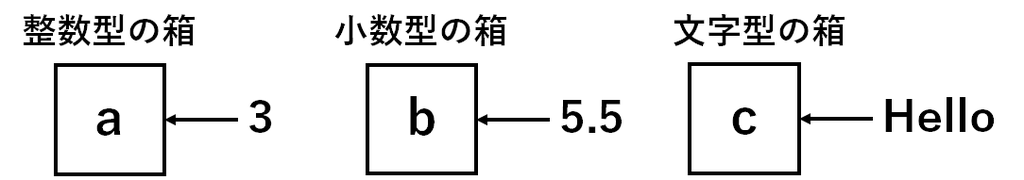

- 変数は以下の例外を除いて自由に名前を付けることができる
  - 変数名の一文字目には数字は使えない
  - +, -, /, %, (, ), # のような演算子や記号は使えない
  - Pythonで予め用意されている予約語(and, as, breakなど)や、組み込みオブジェクト(while、if、sumなど)は使えない
  - 変数名は単純なものよりも、変数がどのような意味を持つかを考えて付けるのが望ましい

```python
# 予約語
__import__('keyword').kwlist
```

```
['False',
 'None',
 'True',
 '__peg_parser__',
 'and',
 'as',
 'assert',
 'async',
 'await',
 'break',
 'class',
 'continue',
 'def',
 'del',
 'elif',
 'else',
 'except',
 'finally',
 'for',
 'from',
 'global',
 'if',
 'import',
 'in',
 'is',
 'lambda',
 'nonlocal',
 'not',
 'or',
 'pass',
 'raise',
 'return',
 'try',
 'while',
 'with',
 'yield']
```

```python
# 組み込みオブジェクト
dir(__builtins__)
```

[output not shown]

[output cut: 101 more lines]

[output not shown]

## 変数の初期化（変数に初めて値を入れる）

- ファイルを閉じなければ、変数の値は以降のセルにも保持される

```python
num1  = 123             # 整数（int型）
num2  = 123.456         # 小数（float型）
text  = "Hello World!"  # 文字列（str型）
judge = True           # 論理型（bool型）, bool値とは、TrueやFalseのような論理値のこと
```

**プログラムの式は、左辺←右辺の操作を意味する。算数や数学の等式とは意味合いが異なることに注意。**

## 変数の画面表示

- 変数にどのような値が代入されているかは、`print関数`で表示できる

**各変数の値を表示**

```python
print(num1)
print(num2)
print(text)
print(judge)
```

```
123
123.456
Hello World!
True
```

**print巻数ではコンマで区切って変数を並べることもできる**  
表示はスペース区切り

```python
print(num1, num2, text, judge)
```

```
123 123.456 Hello World! True
```

## 変数の値を変更

```python
num1  = 987            # 整数型（int）
num2  = 567.23         # 浮動小数点型（float）
text  = "See you."     # 文字列型（str）
judge = False         #  論理型（bool）, TrueかFalseか

print("num1:", num1)
print("num2:", num2)
print("text:", text)
print("judge:", judge)
```

```
num1: 987
num2: 567.23
text: See you.
judge: False
```

## 文字列の切り出し

- `変数名[開始位置:終了位置]`  
  【注意】 実際に切り出される文字列は`開始位置`から`終了位置－1`まで

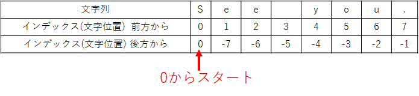

```python
text  = "See you."     # 文字列型（str）

# Seeのみを切り出し
print("前方から:", text[0:3])
print("後方から:", text[0:-5])

# youのみ切り出し
print("前方から:", text[4:7])
print("後方から:", text[-4:-1])

# 文字位置4から最後まで切り出し（終了位置を指定しなくてよい）
print("文字位置以降を切り出し：", text[4:])

# 文字位置2よりも前を切り出し（開始位置を指定しなくてよい）
print("文字位置以前を切り出し：", text[:3]) # 3とすることに注意
```

```
前方から: See
後方から: See
前方から: you
後方から: you
文字位置以降を切り出し： you.
文字位置以前を切り出し： See
```

## 練習

(1) `num3`という名前の変数に「50」の整数を代入した後、print関数で`num3`を表示してみよう

(2) `text1`という名前の変数に「This is an apple.」の文字列を代入した後、print関数で`text1`を表示してみよう

(3) (2)のtext1から`is`を切り出して、print関数で表示してみよう

(4) (2)のtext1から`an apple.`を切り出して、print関数で表示してみよう

解答例

```python
#(1)
num3 = 50
print(num3)
```

```
50
```

```python
#(2)
text1 = "This is an apple."
print(text1)
```

```
This is an apple.
```

```python
#(3)
print(text1[5:7])
```

```
is
```

```python
#(4)
print(text1[8:])
```

```
an apple.
```

# 算術演算子

プログラム上で演算を行うためには、算術演算子を用いる

| 算術演算子 | + | 足し算 |
| --- | --- | --- |
|  | - | 引き算 |
|  | * | かける |
|  | / | 割る（小数） |
|  | // | 割る（整数） |
|  | % | 余り |
|  | ** | べき乗 |

## 算術演算

```python
# 足し算
print("足し算", 10 + 3)

# 引き算
print("引き算", 10 - 3)

# 掛け算
print("掛け算", 10 * 3)

# 割り算
print("割り算", 10 / 3)

# 割り算の商
print("割り算の商", 10 // 3)

# 割り算の余り
print("割り算の余り", 10 % 3)

# べき乗
print("3乗", 10 ** 3)
```

```
足し算 13
引き算 7
掛け算 30
割り算 3.3333333333333335
割り算の商 3
割り算の余り 1
3乗 1000
```

## 変数を使った算術演算

- 変数を使って演算式を書くと、変数の値を書き変えるだけで全ての演算結果が得られる

```python
num1 = 10
num2 = 3

# 足し算
print("足し算", num1 + num2)

# 引き算
print("引き算", num1 - num2)

# 掛け算
print("掛け算", num1 * num2)

# 割り算
print("割り算", num1 / num2)

# 割り算の商
print("割り算の商", num1 // num2)

# 割り算の余り
print("割り算の余り", num1 % num2)

# べき乗
print("3乗", num1 ** num2)
```

```
足し算 13
引き算 7
掛け算 30
割り算 3.3333333333333335
割り算の商 3
割り算の余り 1
3乗 1000
```

## 演算結果を新たな変数に代入して保持

```python
num1 = 10
num2 = 3

# 足し算
tasu = num1 + num2
print("足し算", tasu)

# 引き算
hiku = num1 - num2
print("引き算", hiku)

# 掛け算
kake = num1 * num2
print("掛け算", kake)

# 割り算
waru = num1 / num2
print("割り算", waru)

# 割り算の小
shou = num1 // num2
print("割り算の余り", shou)

# 割り算の余り
amari = num1 % num2
print("割り算の余り", amari)

# べき乗
beki = num1 ** num2
print("3乗", beki)
```

```
足し算 13
引き算 7
掛け算 30
割り算 3.3333333333333335
割り算の余り 3
割り算の余り 1
3乗 1000
```

## 変数の値をx増やす

- プログラムの特有の記述方法がある
- プログラムの式は、左辺←右辺の操作を意味する。算数や数学の等式とは意味合いが異なることに注意。

**パターン1**

```python
num1 = 10

num1 = num1 + 1
print(num1)
```

```
11
```

**パターン2**

```python
num1 = 10

num1 += 1  # num1 = num1 + 1と同じ意味
print(num1)
```

```
11
```

## 文字列の足し算

- 文字列同士を足し算すると結合される

```python
text1 = 'Hello'
text2 = 'World'
print(text1 + text2)
```

```
HelloWorld
```

## 変数の型が異なる場合の演算

- 文字と数値の足し算はできない

```python
num11 = "3" # 文字
num12 =  5  # 数値（整数型）

print(num11 + num12)
```

```
---------------------------------------------------------------------------
TypeError                                 Traceback (most recent call last)
~\AppData\Local\Temp/ipykernel_17624/373290199.py in <module>
      2 num12 =  5  # 数値（整数型）
      3
----> 4 print(num11 + num12)

TypeError: can only concatenate str (not "int") to str
```

### 数値として計算する場合

- `int関数`を用いて数字（文字）を数値(整数型)に変換: `int(数字)`
- `float関数`を用いて数字（文字）を数値(小数型)に変換: `float(数字)`

```python
num11 = "3" # 文字
num12 =  5  # 数値（整数型）

num11 = float(num11)
print(num11 + num12)
```

```
8.0
```

### 文字として計算する場合

- `str関数`を用いて数値を数字（文字）に変換: `str(数値)`

```python
num11 = "3" # 文字
num12 =  5  # 数値（整数型）

num12 = str(num12)
print(num11 + num12)
```

```
35
```

## 練習

(1) 変数num3に`13`、変数num4に`2`を代入した後、２つの変数の割り算の余りを計算し、表示してみよう。

(2) 三角形の面積を計算するプログラムを作成する。底辺を表す変数を`base`、高さを表す変数を`hight`、面積を表す変数を`area`とする。底辺に`13`cm、高さに`4`cmを代入した場合の面積を計算し、表示してみよう。

(3) 球の体積を計算するプログラムを作成する。半径を表す変数を`r`、体積を表す変数を`volume`とする。半径が`7.5`cmの場合の球の体積を計算し、表示してみよう。円周率は3.14とする。

解答例

```python
#(1)
num3 = 13
num4 = 2
print(num3%num4)
```

```
1
```

```python
#(2)
base  = 13
hight = 4
area  = base*hight/2 # 三角形の面積
print(area)
```

```
26.0
```

```python
#(3)
r      = 7.5
volume = 4*3.14*r**3/3  # 球の体積
print(volume)
```

```
1766.25
```